# Week 3 Project

## Cash McGregor

Compiled on Tue Mar 28 22:53:41 2017.

```r
library(DataComputing)
library(mosaicData)
names(CPS85)
```

```
##  [1] "wage"     "educ"     "race"     "sex"      "hispanic" "south"
##  [7] "married"  "exper"    "union"    "age"      "sector"
```

```r
names(NCHS)
```

```
##  [1] "sex"        "age"        "pregnant"   "ethnicity"  "death"
##  [6] "followup"   "smoker"     "diabetic"   "height"     "weight"
## [11] "waist"      "wci"        "bmi"        "ptfat"      "tfat"
## [16] "lfat"       "llean"      "lbmi"       "fbmi"       "bbmi"
## [21] "pfat"       "bmd"        "fmhm_other" "hdl"        "chol"
## [26] "bps"        "bpd"        "income"     "pop_weight" "psu"
## [31] "stratum"
```

# Plot 1

1. This graphic uses a scatter plot to illustrate its data.
2. Wage, exper, sector, and married are used in this graphic.
3. exper is the x-axis variable for all of the faceted graphics, wage is the y-axis for all of the graphics, sector is used to facet the graphics into 8 different graphs, and married is used to distinguish cases in each of the graphics.

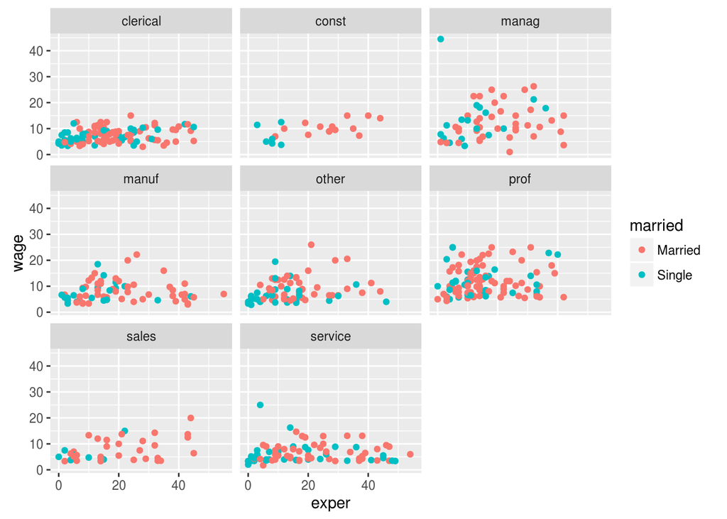

```r
ggplot(data = CPS85, aes(x = exper, y = wage, color = married)) + geom_point() + facet_wrap( ~ sector)
```

# Plot 2

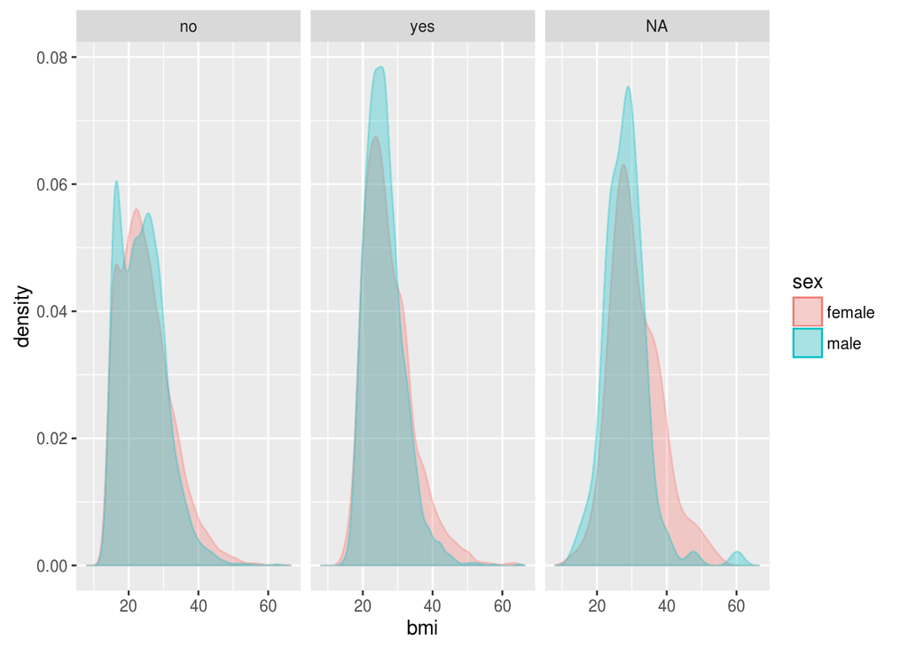

```r
ggplot(data = NCHS, aes(x = bmi)) + geom_density(aes(color = sex, fill=sex ), alpha=0.3) + facet_wrap(~ smoker)
```

# Diamonds

```r
library(ggplot2)
names(diamonds)
```

```
##  [1] "carat"   "cut"     "color"   "clarity" "depth"   "table"   "price"
##  [8] "x"       "y"       "z"
```

```r
diamonds %>%
  group_by(color) %>%
  summarise(msizecolor = mean(carat)) %>%
  arrange(desc( msizecolor )) %>%
  head( 1 )
```

```
## Source: local data frame [1 x 2]
##
##    color msizecolor
##   (fctr)      (dbl)
## 1      J   1.162137
```

1. Color J has the highest average weight of diamond.

```r
diamonds %>%
  group_by(clarity)%>%
  summarise(mtable = mean(table))%>%
  arrange(desc( mtable )) %>%
  head( 1 )
```

```
## Source: local data frame [1 x 2]
##
##   clarity   mtable
##    (fctr)    (dbl)
## 1      I1 58.30378
```

2. I1 has the largest table average among the clarities.

# Voting

```r
names(Minneapolis2013)
```

```
## [1] "Precinct" "First"    "Second"   "Third"    "Ward"
```

1. 80101

```r
Minneapolis2013 %>%
  summarise(total = n())
```

```
##   total
## 1 80101
```

2. Betsy Hodges, Don Samuels, Mark Andrew, undervote, Jackie Cherryhomes

```r
  tally(group_by(Minneapolis2013,Second),sort=TRUE)
```

```
## Source: local data frame [38 x 2]
##
##                Second     n
##                 (chr) (int)
## 1        BETSY HODGES 14399
## 2         DON SAMUELS 14170
## 3         MARK ANDREW 12757
## 4           undervote 10598
## 5  JACKIE CHERRYHOMES  6470
## 6            BOB FINE  3751
## 7          CAM WINTON  3751
## 8           DAN COHEN  2283
## 9  STEPHANIE WOODRUFF  2128
## 10          DOUG MANN  1052
## ..                ...   ...
```

3. 1st: 834 2nd: 10598 3rd: 19210

```r
tally(group_by(Minneapolis2013,First),sort=TRUE)
```

```
## Source: local data frame [38 x 2]
##
##                 First     n
##                 (chr) (int)
## 1        BETSY HODGES 28935
## 2         MARK ANDREW 19584
## 3         DON SAMUELS  8335
## 4          CAM WINTON  7511
## 5  JACKIE CHERRYHOMES  3524
## 6            BOB FINE  2094
## 7           DAN COHEN  1798
## 8  STEPHANIE WOODRUFF  1010
## 9     MARK V ANDERSON   975
## 10          undervote   834
## ..                ...   ...
```

```r
tally(group_by(Minneapolis2013,Second),sort=TRUE)
```

```
## Source: local data frame [38 x 2]
##
##                Second     n
##                 (chr) (int)
## 1        BETSY HODGES 14399
## 2         DON SAMUELS 14170
## 3         MARK ANDREW 12757
## 4           undervote 10598
## 5  JACKIE CHERRYHOMES  6470
## 6            BOB FINE  3751
## 7          CAM WINTON  3751
## 8           DAN COHEN  2283
## 9  STEPHANIE WOODRUFF  2128
## 10          DOUG MANN  1052
## ..                ...   ...
```

```r
tally(group_by(Minneapolis2013,Third),sort=TRUE)
```

```
## Source: local data frame [38 x 2]
##
##                   Third     n
##                   (chr) (int)
## 1             undervote 19210
## 2           DON SAMUELS 11178
## 3           MARK ANDREW  8977
## 4    JACKIE CHERRYHOMES  8045
## 5          BETSY HODGES  6742
## 6              BOB FINE  4506
## 7            CAM WINTON  3974
## 8    STEPHANIE WOODRUFF  2633
## 9             DAN COHEN  2072
## 10 CAPTAIN JACK SPARROW  1440
## ..                  ...   ...
```

4. Mark Andrew, Don Samuels, Jackie Cherryhomes

```r
Betsy <- Minneapolis2013 %>%
  filter(First == "BETSY HODGES")

tally(group_by(Betsy, Second), sort=TRUE)
```

```
## Source: local data frame [38 x 2]
##
##                Second     n
##                 (chr) (int)
## 1         MARK ANDREW  8787
## 2         DON SAMUELS  8743
## 3  JACKIE CHERRYHOMES  2563
## 4           undervote  2238
## 5            BOB FINE  1385
## 6          CAM WINTON  1267
## 7  STEPHANIE WOODRUFF  1007
## 8           DOUG MANN   471
## 9           DAN COHEN   376
## 10    MARK V ANDERSON   376
## ..                ...   ...
```

5. P-6C

```r
Minneapolis2013 %>%
  group_by(Precinct) %>%
  summarise(Fraction = mean(First == "undervote")) %>%
  arrange(desc(Fraction)) %>%
  head(1)
```

```
## Source: local data frame [1 x 2]
##
##   Precinct   Fraction
##      (chr)      (dbl)
## 1     P-6C 0.07738095
```